# Curso PostgreSQL

[figure not shown]

**Autor: Luis Fernando Apáez Álvarez**  
-Curso PyM-  
Clase 4:  
Fecha: Abril del 2023

## Restricciones

Desde hace dos clase hemos estado trabajando con las restricciones sobre nuestras tablas. Dichas restricciones fueron especificamente las *llaves primarias* y *foráneas*, las cuales son de enorme importancia para maneter la integridad de los datos en nuestra BD; asimismo, las restricciones que veremos en esta clase son útiles para maneter dicha integridad.

### Restricción `CHECK`

Comencemos por ver los primeros registros de la tabla `empleados`:

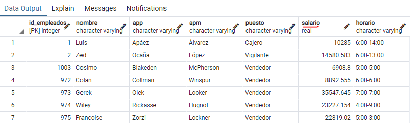

y supongamos, por ejemplo, que por políticas de la empresa ningún empleado puede ganar más de 65000 mensuales. Así como hemos construido nuestra tabla no tendríamos problema alguno en ingresar un empleado cuyo salario exceda esta cifra. Por ello es necesario la implementación de una restricción sobre esta columna para impedir que se ingresen valores superiores a los 65000, lo cual conseguiremos al definir la restricción del tipo `CHECK` sobre al columna `salario`, de modo que con esta retricción logramos controlar los valores que se ingresan en una columna en especifico.

Para agregar dicha restricción escribimos:

```
ALTER TABLE <<nombre_tabla>> ADD CONSTRAINT ck_<<nombre_tabla>>_<<nombre_columna>> CHECK (<<condicion>>)
```

donde notamos que en el `CHECK` debemos definir alguna condición en especifico. En nuestro ejemplo, la condición sería que `salario < 65000`. Por consiguiente, definimos el siguiente `CHECK` sobre la columna `salario`:

```
ALTER TABLE empleados ADD CONSTRAINT ck_empleados_salario CHECK(salario < 65000);
```

cuando lo ejecutemos probablemente nos salga un error que nos diga que dicha restricción es violada por algunos registros en nuestra tabla, es decir, ya existen empleados que ganan más de 65000. En mi caso sólo hay un empleado y éste es:

```
SELECT * FROM empleados WHERE salario > 65000;
```

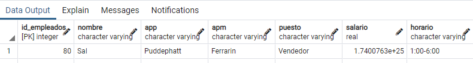

cuyo salario es exorbitante. Recordemos que los datos los generamos de amnera aleatoria, por lo que casos como estos se nos presentan. Se puede solucionar fácilmente este problema si actualizamos el valor del salario para este empleado:

```
UPDATE empleados SET salario = 60000 WHERE id_empleados = 80;
```

nuevamente ejecutamos el código para definir el `CHECK` y ahora no deberíamos tener problemas. Ahora bien, ya hemos definido la restricción `CHECK` sobre la columna `salarios`, de esta forma, si intentaramos ingresar un empleado nuevo o actualizar los datos de un empleado y colocar en la columna `salario` un valor mayor a los 65000 obtendríamos seguramente un error. Comprebemos lo dicho anteriromente

```
INSERT INTO empleados(nombre, app, apm, puesto, salario, horario)
    VALUES('Jenny', 'López', 'López', 'Vendedor', 70000, '7:00-10:00');
```

con lo que obtenemos

[figure not shown]

un error. Así, estamos garantizando que los registros de la tabla `empleados`, en especifico los valores de la columna `salario`, mantenga una integridad de acuerdo a nuestra necesidades. Otro ejemplo de la restricción `CHECK` es en campos referentes al *sexo*. Supongamos que en la tabla `empleados` tenemos una columna destinada al *sexo* del empleado; para esta columna podríamos definir una restricción `CHECK` de la siguiente forma

```
ALTER TABLE empleados ADD CONSTRAINT ck_empleados_sexo
    CHECK(sexo IN ('Masculino', 'Femenino', 'Otro'))
```

donde sólo estamos premitiendo que los valores de la tabla `empleados` en la columna `sexo` sean *Masculino, Femenino* u *Otros*. Así, si llegaramos a ingresar *hombre*, entonces se nos arrojaría un error.

Otro ejemplo común es agregar una restricción `CHECK` sobre columnas de números telefónico. Por ejemplo, supongamos que tenemos la columna `num_tel` en la tabla `empleados` y deseamos que no sean ingresados números telefónicos con más de 10 cifras, o que lleguen a ingresarse números telefónicos con alguna letra. Entonces emplearemos la siguiente restricción `CHECK` sobre la columna `num_tel`

```
ALTER TABLE empleados ADD CONSTRAINT ck_empleados_num_tel
    CHECK(num_tel ~ '[0-9][0-9][0-9][0-9][0-9][0-9][0-9][0-9][0-9][0-9]')
```

```
ALTER TABLE empleados DROP CONSTRAINT ck_empleados_salario;
```

es decir, la sintaxis general para eliminar una restricción `CHECK` es

```
ALTER TABLE <<nombre_tabla>> DROP CONSTRAINT ck_<<nombre_tabla>>_<<nombre_columna>>;
```

### Restricción `NOT NULL`

Hay veces en las que no podemos permitir valores nulos dentro de una columna. Por ejemplo, en la tabla `empleados`, en la columna `puesto` debemos especificar para cada uno de los empleados el puesto que éstos llevarán a cabo. Así, de manera general, la restricción `NOT NULL` nos sirve para forzar el ingreso de datos para ciertas columnas.

Para definir esta restricción sobre la columna `puesto` escribimos

```
ALTER TABLE empleados ALTER COLUMN puesto SET NOT NULL;
```

de tal manera, si nosotros intentamos registrar a un empleado nuevo y omitimos el valor correspondiente a la columna `puesto`, entonces *postgres* nos arrojará un error:

```
INSERT INTO empleados(nombre, app, apm, salario, horario)
    VALUES('Jenny', 'López', 'López', 10000, '6:00-9:00');
```

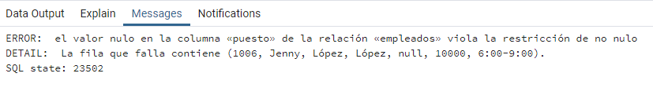

### Restricción `unique`

Como vimos en la restricción de *llave primaria* al definirla sobre una columna, dentro de esta columna no se aceptarán valores repetidos. Es decir, si definimos la llave primaria, por ejemplo, sobre el `id_empleados` de la tabla `empleados`, entonces no se pirmitirán id's repetidos.

La restricción `unique` actúa de manera muy similar, pues al definir ésta sobre alguna columna, no se permitirán valores duplicados. Sin embargo, dicha columna no tiene la características principales para ser considerada como llave primaria dentro de esta tabla y además ésta permite valores nulos (lo cual la llave primaria no permite). Por ejemplo, si en la tabla `empleados` tuvieramos una columna denominada `curp`, entonces sería necesario definir la restricción `unique` para dicha columna, lo cual conseguiríamos escribiendo

```
ALTER TABLE empleados ADD CONSTRAINT uq_empleados_curp UNIQUE(curp);
```

*Observación:* El proceso que estamos siguiendo para definir las restricciones no es el mejor, si bien es ilustrativo, éste debe realizarse desde que definimos las tablas y no después como lo estamos haciendo ahora. De tal manera, lo primero que se debe hacer en un proyecto es pensar las tablas que se crearán, pensar las columnas de cada tabla y definir las restricciones sobre las columnas que sean necesarias.

Por ende, la forma en la que estamos llevando el curso es, primero, aprender el código SQL y, después, sobre la marcha ir modificando el proyecto, lo cual es bastante ilustrativo y práctico; sin embargo no es la forma correcta de trabajar, pero, una vez que finalices el curso tendrás de igual manera las herramientas que te peritan trabajar con proyectos de la mejor forma posibble.

### Ejercicio

1. Dentro de la tabla `productos` tenemos distintos productos que vendemos en la papelería. Use el siguiente código

   ```
   SELECT DISTINCT nombre_productos FROM productos;
   ```

   para conocer todos los productos que se venden en la papelería.

    a. Define una restricción `CHECK` sobre la columna `nombre_productos` de la tabla `productos`, basándote en la información que obtuviste de la consulta anterior.

    b. Intenta ingresar un registro que viole la restricción creada en el punto anterior.

    c. Elimina la restricción creada en el punto a.
2. Elige cualquiera de tus tablas y coloca una restricción de no nulidad en alguna de sus columnas, así como una restricción `UNIQUE`

## Rellenando nuestras tablas con información falsa

Hasta el momento, al menos en las tres tablas que trabajamos en clase (`empleados, ventas` y `productos`) ya hemos definidos las principales restricciones: las llaves primarias y foráneas. Con lo anterior garantizamos la integridad de nuestros datos y evitamos errores a la hora de ingresar información en cada una de ellas.

Ahora bien, para trabajar de la mejor forma en clases posteriores ingresaremos bastantes filas a nuestras tres tablas base (las que mencionamos antes), lo que nos permitirá introducirnos a manejar bases de datos con muchos registros. Realizaremos pues 1000 inserciones en las tablas `empleados, ventas` y `productos`, pero no ingresaremos de forma manual todas esta información, nos auxiliaremos de la página [mockaroo](https://www.mockaroo.com/) para generar las 1000 inserciones. En dicha página se creará de forma aleatoria la información que le pidamos, de acuerdo al tipo de dato de las columnas de nuestras tablas.

Una vez en la página de mockaroo veremos algo como

[figure not shown]

Primero generaremos la información para las tablas `empleados` y `productos`, pues recordemos que en la tabla `ventas` hay dos columnas con llaves foráneas que depende de la información de estas primeras dos tablas.

### Para la tabla `empleados`.

Comenzamos por realizar una consulta

```
SELECT * FROM empleados;
```

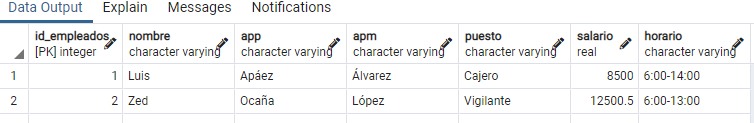

con base en lo anterior escribimos en mockaroo

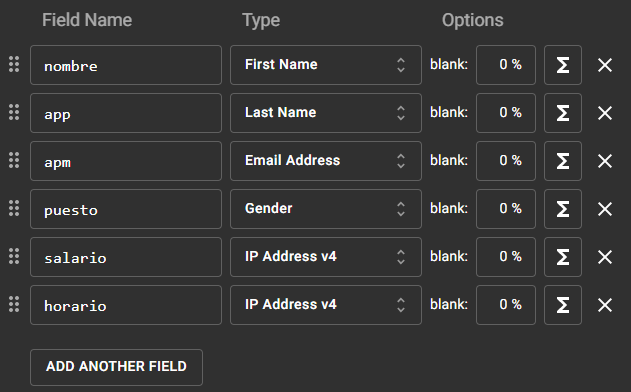

es decir, comenzamos colocando el nombre de las columnas de la tabla. Posteriormente agregamos el tipo de dato que le corresponde

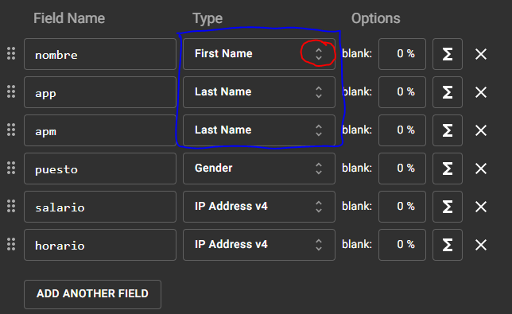

agregamos el tipo de dato para las columnas `nombre, app, apm` buscando en el menú que se despliega de pulsar en las flechas (lo que está en color rojo). En la columna `nombre` se generarán nombres aleatorios (*first name*) y en las columnas `app, apm` se generarán apellidos (*last name*). Después, trabajaremos con las columnas `salario` y `horario`. Para salario, en el menú que se despliega de pulsar la flechas buscaremos la opción *number*

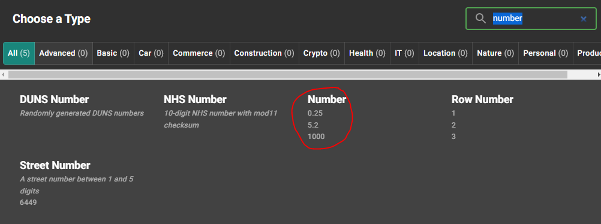

lo que nos arroja

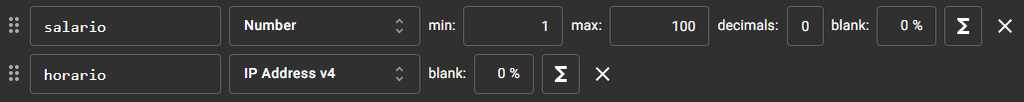

y personalizamos los valores para la columna salario. En nuestro caso colocamos

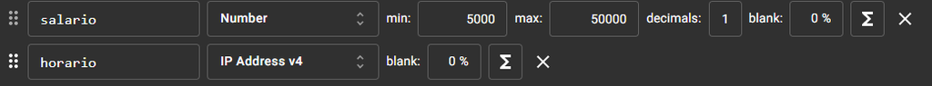

Después pasamos a la columna `horario`. Para ello, como le hicimos en la columna anterior, buscamos *character sequence*, con lo que obtendremos

[figure not shown]

y después lo personalizamos como

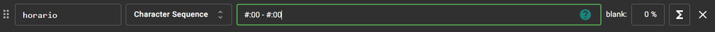

si tienes dudas de porqué colocamos lo anterior puedes pulsar el símbolo de ayuda y mockaroo arrojará una breve guía

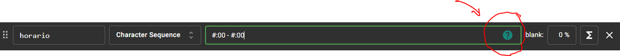

Finalmente, en la columna `puesto` utilizaremos un poco de programación, pues en nuestro caso los puestos de trabajo son muy específicos. Supondremos que sólo hay cuatro puestos de trabajo en la papelería: cajero, vendedor, vigilante y limpieza. Para conseguir asignar a cada uno de los 1000 empleados que generaremos un puesto de trabajo haremos lo siguiente:

- A cada empleado le asignaremos un número de la siguiente forma: al primer empleado de la tabla le asignamos el 1, al segundo el 2, etcétera. Esto lo conseguimos con *row number*:

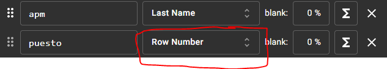

- Después pulsamos el botón sigma, el cual nos permite escribir código

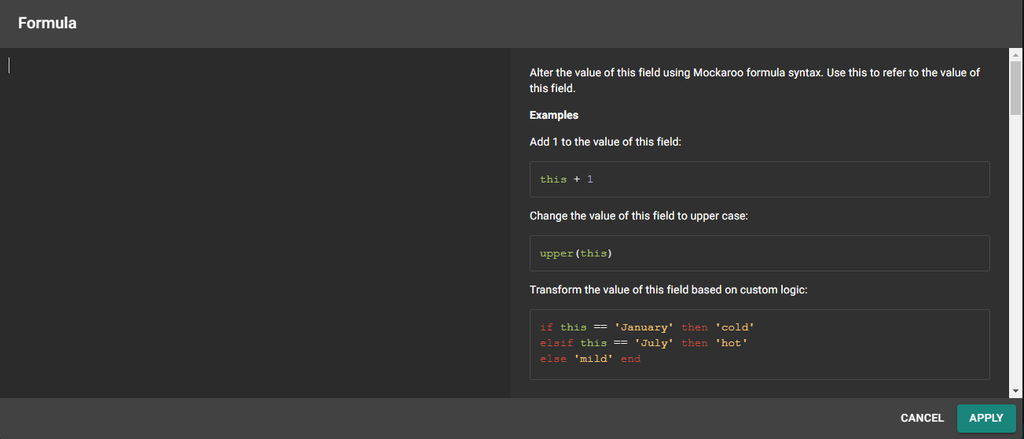

Ahí, la idea será la siguiente:

1. A los primeros 250 empleados, que tienen asignados los números del 1 al 250 en la columna `puesto` (lo cual conseguimos al colocar en puesto _row *number* en mockaroo) les asignaremos el puesto de trabajo de cajero. El código que emplearemos será:

```
if puesto <= 250 then 'cajero'
```

es decir, si el número asignado al puesto es menor o igual a 250 entonces escribiremos en la columna `puesto` *cajero*.

1. A los empleados entre el 250 y 500 les asignaremos el puesto de trabajo de vendedor:

```
elsif puesto <= 500 and puesto > 250 then 'vendedor'
```

Y el resto queda como

```
elsif puesto <= 750 and puesto > 500 then 'vigilante'
else 'limpieza' end
```

En mockaroo tendríamos

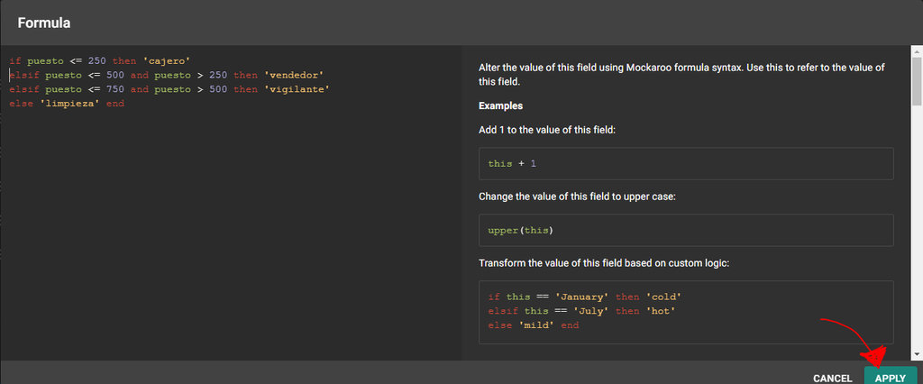

pulsamos *Apply* para aplicar la fórmula del código que escribimos. Después previsualizamos los datos que se generaron. Para ello, en la pestaña principal pulsamos en *Preview*

[figure not shown]

donde:

1. Nos arroja la previsualización de los datos que generamos, en nuestro caso:

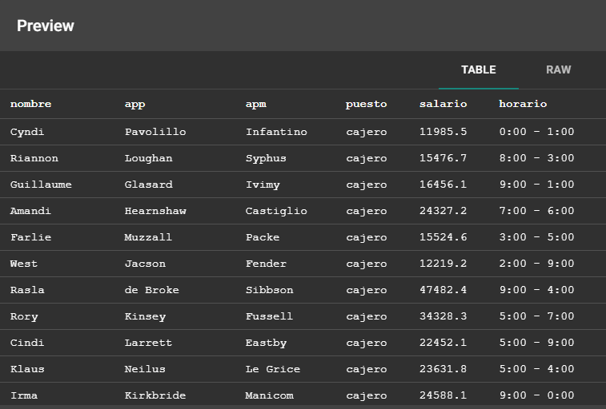

1. Pulsamos en *Format* y buscamos la opción de *sql*

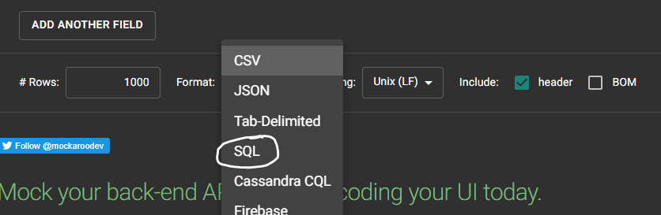

una vez seleccionada la opción de *SQL* nos aparecerá una opción a la derecha denominada *Table Name*. En ella eliminamos el texto _MOCK_DATA_ y colocamos el nombre de nuestra tabla, la cual es `empleados`

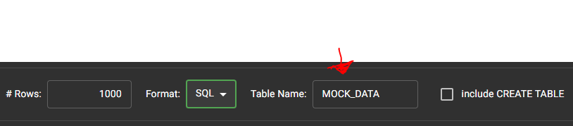

Finalmente:

1. Descargamos el archivo .sql pulsando en *download data*. Es importante saber la ruta donde descargamos dicho archivo.

Ahora bien, realizaremos las 1000 inserciones en la tabla `empleados`, las cuales tenemos ya en el archivo que descargamos. No obstante, no iremos a *pgAdmin* para efectuar dichas inserciones pues muy seguramente esto sería muy lento debido al número de inserciones que creamos en el archivo .sql, además podríamos correr el riesgo de que nuestra pc se trabe. Para solucionar esto trabajaremos directamente con postgres. Cabe resaltar que *pgAdmin* es un cliente postgres, es decir, en él podemos utilizar posgres, siendo así que éste es un intermediario entre el usuario (nosotros) y PostgreSQL.

Para interactuar de manera directa con posgres utilizaremos la consola *psql* la cual descargamos en conjunto con *pgAdmin*. Para ello iremos al buscador de aplicaciones y escribimos justamente *psql*. Después de abrirlo nos debe arrojar la siguiente ventana

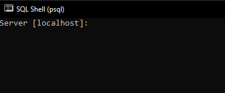

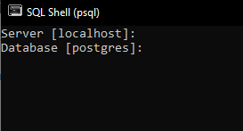

que hace alusión a la base de datos con la cual queremos trabajar. En mi caso, las tablas `empleados, ventas, productos` se encuentran en una base de datos denominada *CursoPostgres*, por lo que en

```
Database [postgres]:
```

colocaremos *CursoPostgres*. Después damos enter hasta que nos pide la contraseña que registramos en *pgAdmin*

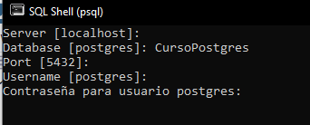

una vez ingresada la contraseña damos enter y nos debería de aparecer algo como

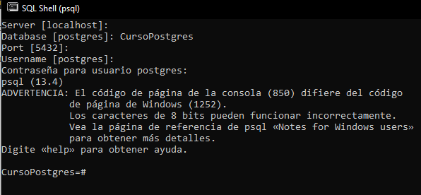

con lo cual hemos logrado realizar la conexión directa con postgres. De hecho, desde dicha consola (y una vez realizada la conexión) podemos utilizar código sql. Por ejemplo, desde la consola podemos realizar una consulta

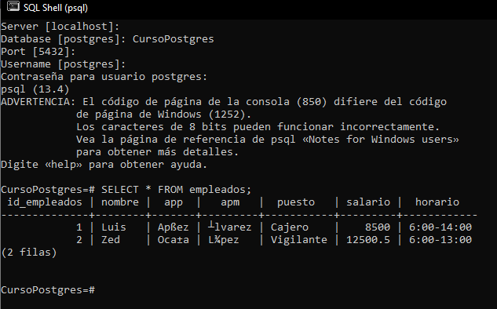

Ahora bien, cerramos la consola *psql* y ahora abrimos *símbolos del sistema*. Ahí, escribiremos

```
cd C:\Program Files\PostgreSQL\13\bin
```

En mi caso escribí esa dirección, pero puede que en tu pc dicho archivo tenga otra dirrección y que la versión sea superior a la 13. Para hallar la dirección debes ir a **archivos>>este equipo>>Disco local>> archivos de programa** y buscar la carpeta PostgreSQL. La abrimos hasta llegar a la carpeta **bin** , abrimos también esta carpeta y copiamos dicha dirección para después pegarla en la consola

[figure not shown]

Ahora, en la consola escribimos `psql -U postgres -d CursoPostgres -f " "` donde colocaremos entre las comillas la dirección donde guardamos el archivo .sql que descargamos de mockaroo:

```
psql -U postgres -d CursoPostgres -f "C:\Users\weeee\OneDrive\Escritorio\empleados.sql"
```

Note que escribimos `-d CursoPostgres`, es decir, después de `-d` escribimos el nombre de la base de datos que contiene la tabla `empleados`.

Una vez que damos enter se nos pedirá la contraseña del postgres. Así, cuando damos enter en la contraseña se comenzarán a ejecutar los inserts en la tabla `empleados`

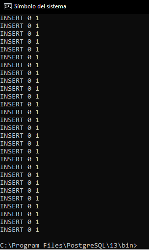

Así, los inserts se han ejecutado. Después veamos los resultados en *pgAdmin*

```
-- Realizamos la consulta
SELECT * FROM empleados;
```

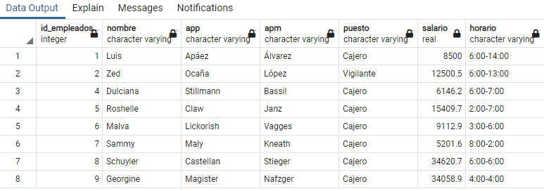

[figure not shown]